# Introduction

## Research direction

Our research aims to find which factors contribute most to shopping behavior. Nowadays, online shopping become one of the most important parts of the business world. It is necessary to grasp the user’s buying habits and predict their shopping intention. Using these analysis results and prediction to improve shopping websites and applications can improve the sales and profit of these companies.

## Rational

These data on users’ activities and shopping behavior have some relationships. And these relationships can be used to build a prediction model to predict users’ intentions. In that case, online shopping websites can improve their design and push more exact commodities and repo to get higher sales and profit. Meanwhile, customers will have a better shopping experience. Moreover, this analysis is a good reference for a merchant to improve their service and product. Shopping websites and applications also can refer to this model for their marketing strategy. Therefore, this research is meaningful and beneficial to many parties.

## Methods

We will use several models to predict customers' intentions to purchase products online. These models will help us identify the most significant variables that affect customers' behavior and preferences. Additionally, we will use data visualization techniques to explore the relationships between variables and provide a clear understanding of the data.

## Dateset Description

The dataset is about customers’ scanning time, exiting rate, browsing pages, and other information which is relevant to their shopping intention. The dataset is highly consistent with our study. It includes almost every element we’d like to analyze.

## Column Descriptions

Administrative: This is the number of pages of this type (administrative) that the user visited

Administrative_ Duration: This is the amount of time spent in this category of pages

Informational: This is the number of pages of this type (informational) that the user visited

informational_ Duration: This is the amount of time spent in this category of pages

ProductRelated: This is the number of pages of this type (product related) that the user visited

ProductRelated Duration: This is the amount of time spent in this category of pages

BounceRates: The percentage of visitors who enter the website through that page and exit without triggering any additionaltasks

ExitRates: The percentage of pageviews on the website that end at that specific page

PageValues: The average value of the page averaged over the value of the target page and/or the completion of an eCommercetransaction

SpecialDay: This value represents the closeness of the browsing date to special days or holidays (eg Mother's Day) in which the transaction is more likely to be finalized

Month: Contains the month the pageview occurred, in string form

OperatingSystems: An integer value representing the operating svstem that the user was on when viewing the page

Browser: An integer value representing the browser that the user was using to view the page

Region: An integer value representing which region the user is located in

TrafficType: An integer value representing what type of traffic the user is categorized into

VisitorType: A string representing whether a visitor is New Visitor, Returning Visitor, or Other

Weekend: A boolean representing whether the session is on a weekend

Revenue: A boolean representing whether or not the user completed the purchase

# Data Processing

```python
import pandas as pd
import numpy as np
import matplotlib.pyplot as plt
```

```python
df = pd.read_csv('/Users/dandanren/Desktop/proposal/online_shoppers_intention.csv')
df.head()
```

|  | Administrative | Administrative_Duration | Informational | Informational_Duration | ProductRelated | ProductRelated_Duration | BounceRates | ExitRates | PageValues | SpecialDay | Month | OperatingSystems | Browser | Region | TrafficType | VisitorType | Weekend | Revenue |
| --- | --- | --- | --- | --- | --- | --- | --- | --- | --- | --- | --- | --- | --- | --- | --- | --- | --- | --- |
| 0 | 0 | 0.0 | 0 | 0.0 | 1 | 0.000000 | 0.20 | 0.20 | 0.0 | 0.0 | Feb | 1 | 1 | 1 | 1 | Returning_Visitor | False | False |
| 1 | 0 | 0.0 | 0 | 0.0 | 2 | 64.000000 | 0.00 | 0.10 | 0.0 | 0.0 | Feb | 2 | 2 | 1 | 2 | Returning_Visitor | False | False |
| 2 | 0 | 0.0 | 0 | 0.0 | 1 | 0.000000 | 0.20 | 0.20 | 0.0 | 0.0 | Feb | 4 | 1 | 9 | 3 | Returning_Visitor | False | False |
| 3 | 0 | 0.0 | 0 | 0.0 | 2 | 2.666667 | 0.05 | 0.14 | 0.0 | 0.0 | Feb | 3 | 2 | 2 | 4 | Returning_Visitor | False | False |
| 4 | 0 | 0.0 | 0 | 0.0 | 10 | 627.500000 | 0.02 | 0.05 | 0.0 | 0.0 | Feb | 3 | 3 | 1 | 4 | Returning_Visitor | True | False |

```python
# Null values checking
df.isnull().sum()
```

```
Administrative             0
Administrative_Duration    0
Informational              0
Informational_Duration     0
ProductRelated             0
ProductRelated_Duration    0
BounceRates                0
ExitRates                  0
PageValues                 0
SpecialDay                 0
Month                      0
OperatingSystems           0
Browser                    0
Region                     0
TrafficType                0
VisitorType                0
Weekend                    0
Revenue                    0
dtype: int64
```

```python
 len(df[df['ProductRelated_Duration'] == 0])
```

```
755
```

Although we don't have missing value in the dataset, we must drop data whose ProductRelated_Duration is equal to 0. Because we cannot develop our Kaplan Meier model with a 0 duration. From this perspect, we could regard these 755 rows data as our null value.

```python
df.info()
```

```
<class 'pandas.core.frame.DataFrame'>
RangeIndex: 12330 entries, 0 to 12329
Data columns (total 18 columns):
 #   Column                   Non-Null Count  Dtype
---  ------                   --------------  -----
 0   Administrative           12330 non-null  int64
 1   Administrative_Duration  12330 non-null  float64
 2   Informational            12330 non-null  int64
 3   Informational_Duration   12330 non-null  float64
 4   ProductRelated           12330 non-null  int64
 5   ProductRelated_Duration  12330 non-null  float64
 6   BounceRates              12330 non-null  float64
 7   ExitRates                12330 non-null  float64
 8   PageValues               12330 non-null  float64
 9   SpecialDay               12330 non-null  float64
 10  Month                    12330 non-null  object
 11  OperatingSystems         12330 non-null  int64
 12  Browser                  12330 non-null  int64
 13  Region                   12330 non-null  int64
 14  TrafficType              12330 non-null  int64
 15  VisitorType              12330 non-null  object
 16  Weekend                  12330 non-null  bool
 17  Revenue                  12330 non-null  bool
dtypes: bool(2), float64(7), int64(7), object(2)
memory usage: 1.5+ MB
```

```python
df.describe()
```

|  | Administrative | Administrative_Duration | Informational | Informational_Duration | ProductRelated | ProductRelated_Duration | BounceRates | ExitRates | PageValues | SpecialDay | OperatingSystems | Browser | Region | TrafficType |
| --- | --- | --- | --- | --- | --- | --- | --- | --- | --- | --- | --- | --- | --- | --- |
| count | 12330.000000 | 12330.000000 | 12330.000000 | 12330.000000 | 12330.000000 | 12330.000000 | 12330.000000 | 12330.000000 | 12330.000000 | 12330.000000 | 12330.000000 | 12330.000000 | 12330.000000 | 12330.000000 |
| mean | 2.315166 | 80.818611 | 0.503569 | 34.472398 | 31.731468 | 1194.746220 | 0.022191 | 0.043073 | 5.889258 | 0.061427 | 2.124006 | 2.357097 | 3.147364 | 4.069586 |
| std | 3.321784 | 176.779107 | 1.270156 | 140.749294 | 44.475503 | 1913.669288 | 0.048488 | 0.048597 | 18.568437 | 0.198917 | 0.911325 | 1.717277 | 2.401591 | 4.025169 |
| min | 0.000000 | 0.000000 | 0.000000 | 0.000000 | 0.000000 | 0.000000 | 0.000000 | 0.000000 | 0.000000 | 0.000000 | 1.000000 | 1.000000 | 1.000000 | 1.000000 |
| 25% | 0.000000 | 0.000000 | 0.000000 | 0.000000 | 7.000000 | 184.137500 | 0.000000 | 0.014286 | 0.000000 | 0.000000 | 2.000000 | 2.000000 | 1.000000 | 2.000000 |
| 50% | 1.000000 | 7.500000 | 0.000000 | 0.000000 | 18.000000 | 598.936905 | 0.003112 | 0.025156 | 0.000000 | 0.000000 | 2.000000 | 2.000000 | 3.000000 | 2.000000 |
| 75% | 4.000000 | 93.256250 | 0.000000 | 0.000000 | 38.000000 | 1464.157214 | 0.016813 | 0.050000 | 0.000000 | 0.000000 | 3.000000 | 2.000000 | 4.000000 | 4.000000 |
| max | 27.000000 | 3398.750000 | 24.000000 | 2549.375000 | 705.000000 | 63973.522230 | 0.200000 | 0.200000 | 361.763742 | 1.000000 | 8.000000 | 13.000000 | 9.000000 | 20.000000 |

## Dataset Summary

```python
data = pd.get_dummies(df)
data.head()
```

|  | Administrative | Administrative_Duration | Informational | Informational_Duration | ProductRelated | ProductRelated_Duration | BounceRates | ExitRates | PageValues | SpecialDay | ... | Month_Jul | Month_June | Month_Mar | Month_May | Month_Nov | Month_Oct | Month_Sep | VisitorType_New_Visitor | VisitorType_Other | VisitorType_Returning_Visitor |
| --- | --- | --- | --- | --- | --- | --- | --- | --- | --- | --- | --- | --- | --- | --- | --- | --- | --- | --- | --- | --- | --- |
| 0 | 0 | 0.0 | 0 | 0.0 | 1 | 0.000000 | 0.20 | 0.20 | 0.0 | 0.0 | ... | 0 | 0 | 0 | 0 | 0 | 0 | 0 | 0 | 0 | 1 |
| 1 | 0 | 0.0 | 0 | 0.0 | 2 | 64.000000 | 0.00 | 0.10 | 0.0 | 0.0 | ... | 0 | 0 | 0 | 0 | 0 | 0 | 0 | 0 | 0 | 1 |
| 2 | 0 | 0.0 | 0 | 0.0 | 1 | 0.000000 | 0.20 | 0.20 | 0.0 | 0.0 | ... | 0 | 0 | 0 | 0 | 0 | 0 | 0 | 0 | 0 | 1 |
| 3 | 0 | 0.0 | 0 | 0.0 | 2 | 2.666667 | 0.05 | 0.14 | 0.0 | 0.0 | ... | 0 | 0 | 0 | 0 | 0 | 0 | 0 | 0 | 0 | 1 |
| 4 | 0 | 0.0 | 0 | 0.0 | 10 | 627.500000 | 0.02 | 0.05 | 0.0 | 0.0 | ... | 0 | 0 | 0 | 0 | 0 | 0 | 0 | 0 | 0 | 1 |

5 rows × 29 columns

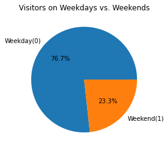

```python
#draw a pie chart to show df['Weekend']
import matplotlib.pyplot as plt

# count the number of visitors who visited on weekends vs. weekdays
weekend_count = data['Weekend'].value_counts()

# create a pie chart
plt.pie(weekend_count, labels=['Weekday(0)', 'Weekend(1)'], autopct='%1.1f%%')
plt.title('Visitors on Weekdays vs. Weekends')
plt.show()
```

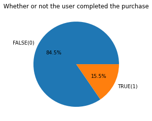

```python
#draw a pie chart to show df['Revenue']
import matplotlib.pyplot as plt

# count the number of visitors who visited on weekends vs. weekdays
Revenue_count = data['Revenue'].value_counts()

# create a pie chart
plt.pie(Revenue_count, labels=['FALSE(0)', 'TRUE(1)'], autopct='%1.1f%%')
plt.title('Whether or not the user completed the purchase')
plt.show()
```

## Kaplan-Meier analysis

For this dataset, we can define the event as a website visitor to make a purchase on the site. We can use the Revenue column to identify whether a purchase was made or not.

The time variable would be the duration of the visit, which we can use the ProductRelated_Duration column to represent. This column represents the amount of time that the user spent on product-related pages, which could be a good proxy for the overall duration of the visit.

So we will define the event as purchasing (Revenue = TRUE) and the time variable as the duration of the visit (ProductRelated_Duration)

```python
# The unit for duration is second, convert it into minute.
df['ProductRelated_Duration'] = df['ProductRelated_Duration'] / 60

# Round up duration and convert it into integers
df['ProductRelated_Duration'] = df['ProductRelated_Duration'].round().astype(int)

# Eliminate duration equal to 0
df = df[df['ProductRelated_Duration'] != 0]
```

```python
pd.crosstab(df.ProductRelated_Duration, df.Revenue, margins=True, margins_name="Total")
```

| Revenue ProductRelated_Duration | False | True | Total |
| --- | --- | --- | --- |
| 1 | 803 | 36 | 839 |
| 2 | 673 | 42 | 715 |
| 3 | 587 | 40 | 627 |
| 4 | 524 | 46 | 570 |
| 5 | 434 | 58 | 492 |
| ... | ... | ... | ... |
| 450 | 0 | 1 | 1 |
| 500 | 1 | 0 | 1 |
| 720 | 1 | 0 | 1 |
| 1066 | 1 | 0 | 1 |
| Total | 9300 | 1871 | 11171 |

217 rows × 3 columns

```python
import lifelines
from lifelines import KaplanMeierFitter
```

```python
kmf = KaplanMeierFitter()
kmf.fit(df.ProductRelated_Duration, df.Revenue,label='Kaplan Meier Estimate')
```

```
<lifelines.KaplanMeierFitter:"Kaplan Meier Estimate", fitted with 11171 total observations, 9300 right-censored observations>
```

```python
kmf.survival_function_
```

| timeline | Kaplan Meier Estimate |
| --- | --- |
| 0.0 | 1.000000 |
| 1.0 | 0.996777 |
| 2.0 | 0.992725 |
| 3.0 | 0.988596 |
| 4.0 | 0.983538 |
| ... | ... |
| 414.0 | 0.117828 |
| 450.0 | 0.088371 |
| 500.0 | 0.088371 |
| 720.0 | 0.088371 |
| 1066.0 | 0.088371 |

217 rows × 1 columns

```python
ci = kmf.confidence_interval_survival_function_
ci
```

|  | Kaplan Meier Estimate_lower_0.95 | Kaplan Meier Estimate_upper_0.95 |
| --- | --- | --- |
| 0.0 | 1.000000 | 1.000000 |
| 1.0 | 0.995535 | 0.997674 |
| 2.0 | 0.990925 | 0.994170 |
| 3.0 | 0.986353 | 0.990473 |
| 4.0 | 0.980832 | 0.985864 |
| ... | ... | ... |
| 414.0 | 0.072673 | 0.174759 |
| 450.0 | 0.038522 | 0.164047 |
| 500.0 | 0.038522 | 0.164047 |
| 720.0 | 0.038522 | 0.164047 |
| 1066.0 | 0.038522 | 0.164047 |

217 rows × 2 columns

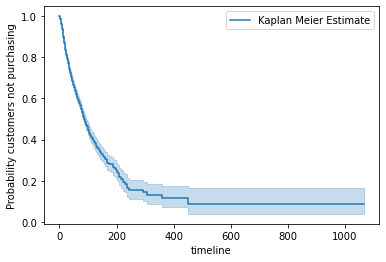

```python
kmf.plot(ci_show=True)
plt.ylabel('Probability customers not purchasing')
```

### Conclusion

As the browsing time grows, the probability of users not buying gradually decreases, meaning that the probability of customers buying increases.

### Compare different groups' survival probability

```python
groups = df['SpecialDay']

i1 = (groups >= 0.5)
i2 = (groups < 0.5)
```

```python
T = df['ProductRelated_Duration']
E = df['Revenue']
```

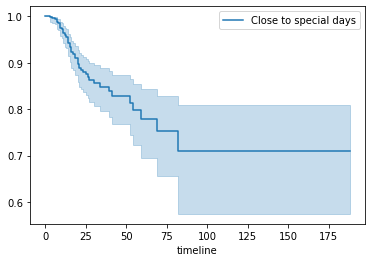

```python
kmf1 = KaplanMeierFitter()
kmf1.fit(T[i1], E[i1], label='Close to special days')
kmf1.plot()
```

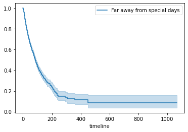

```python
kmf2 = KaplanMeierFitter()
kmf2.fit(T[i2], E[i2], label='Far away from special days')
kmf2.plot()
```

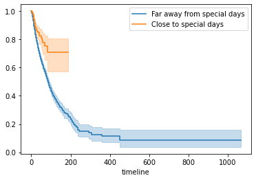

```python
kmf2.plot()
kmf1.plot()
```

### Conclusion

With the same duration, closer to special holidays, the higher the non-purchase rate of users, the lower the purchase rate. The presumed reason may be that near the holidays, users are more inclined to purchase like brick-and-mortar stores.

```python
groups2 = df['VisitorType']

v1 = (groups2 == "Returning_Visitor")
v2 = (groups2 == "New_Visitor")
```

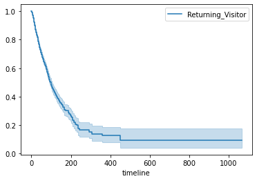

```python
kmf3 = KaplanMeierFitter()
kmf3.fit(T[v1], E[v1], label='Returning_Visitor')
kmf3.plot()
```

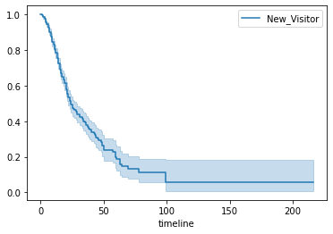

```python
kmf4 = KaplanMeierFitter()
kmf4.fit(T[v2], E[v2], label='New_Visitor')
kmf4.plot()
```

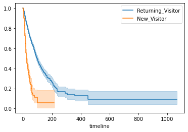

```python
kmf3.plot()
kmf4.plot()
```

### Conclusion

This Kaplan Meier Model cannot tell us which are the most important factors for revenue. We are going to develop another two models for further analysis.

## Cox Regression

Proportional hazards regression, also known as Cox regression, is a type of regression analysis used to model the relationship between the survival time of an event and one or more predictor variables, also known as covariates.

```python
from lifelines import CoxPHFitter
```

```python
cox_data = pd.get_dummies(df, columns=['VisitorType', 'Weekend'])
```

```python
cox_data.head()
```

|  | Administrative | Administrative_Duration | Informational | Informational_Duration | ProductRelated | ProductRelated_Duration | BounceRates | ExitRates | PageValues | SpecialDay | ... | OperatingSystems | Browser | Region | TrafficType | Revenue | VisitorType_New_Visitor | VisitorType_Other | VisitorType_Returning_Visitor | Weekend_False | Weekend_True |
| --- | --- | --- | --- | --- | --- | --- | --- | --- | --- | --- | --- | --- | --- | --- | --- | --- | --- | --- | --- | --- | --- |
| 1 | 0 | 0.0 | 0 | 0.0 | 2 | 1 | 0.000000 | 0.100000 | 0.0 | 0.0 | ... | 2 | 2 | 1 | 2 | False | 0 | 0 | 1 | 1 | 0 |
| 4 | 0 | 0.0 | 0 | 0.0 | 10 | 10 | 0.020000 | 0.050000 | 0.0 | 0.0 | ... | 3 | 3 | 1 | 4 | False | 0 | 0 | 1 | 0 | 1 |
| 5 | 0 | 0.0 | 0 | 0.0 | 19 | 3 | 0.015789 | 0.024561 | 0.0 | 0.0 | ... | 2 | 2 | 1 | 3 | False | 0 | 0 | 1 | 1 | 0 |
| 8 | 0 | 0.0 | 0 | 0.0 | 2 | 1 | 0.000000 | 0.100000 | 0.0 | 0.8 | ... | 2 | 2 | 2 | 3 | False | 0 | 0 | 1 | 1 | 0 |
| 9 | 0 | 0.0 | 0 | 0.0 | 3 | 12 | 0.000000 | 0.022222 | 0.0 | 0.4 | ... | 2 | 4 | 1 | 2 | False | 0 | 0 | 1 | 1 | 0 |

5 rows × 21 columns

```python
covariates = ['Administrative', 'Administrative_Duration', 'Informational_Duration',
              'ProductRelated',  'PageValues', 'SpecialDay',
              'OperatingSystems', 'Region','ProductRelated_Duration','Revenue']
```

```python
cph = CoxPHFitter()
cph.fit(cox_data[covariates], duration_col='ProductRelated_Duration', event_col='Revenue')
cph.print_summary()
```

| model | lifelines.CoxPHFitter |
| --- | --- |
| duration col | 'ProductRelated_Duration' |
| event col | 'Revenue' |
| baseline estimation | breslow |
| number of observations | 11171 |
| number of events observed | 1871 |
| partial log-likelihood | -13907.86 |
| time fit was run | 2023-04-26 19:34:10 UTC |

|  | coef | exp(coef) | se(coef) | coef lower 95% | coef upper 95% | exp(coef) lower 95% | exp(coef) upper 95% | cmp to | z | p | -log2(p) |
| --- | --- | --- | --- | --- | --- | --- | --- | --- | --- | --- | --- |
| Administrative | 0.03 | 1.03 | 0.01 | 0.01 | 0.05 | 1.01 | 1.05 | 0.00 | 3.70 | <0.005 | 12.18 |
| Administrative_Duration | -0.00 | 1.00 | 0.00 | -0.00 | -0.00 | 1.00 | 1.00 | 0.00 | -4.80 | <0.005 | 19.26 |
| Informational_Duration | -0.00 | 1.00 | 0.00 | -0.00 | -0.00 | 1.00 | 1.00 | 0.00 | -3.24 | <0.005 | 9.69 |
| ProductRelated | -0.02 | 0.98 | 0.00 | -0.02 | -0.02 | 0.98 | 0.98 | 0.00 | -25.38 | <0.005 | 469.68 |
| PageValues | 0.02 | 1.02 | 0.00 | 0.01 | 0.02 | 1.01 | 1.02 | 0.00 | 39.70 | <0.005 | inf |
| SpecialDay | -0.97 | 0.38 | 0.19 | -1.35 | -0.60 | 0.26 | 0.55 | 0.00 | -5.14 | <0.005 | 21.77 |
| OperatingSystems | -0.12 | 0.88 | 0.03 | -0.18 | -0.07 | 0.84 | 0.93 | 0.00 | -4.50 | <0.005 | 17.15 |
| Region | -0.03 | 0.97 | 0.01 | -0.05 | -0.01 | 0.95 | 0.99 | 0.00 | -2.94 | <0.005 | 8.23 |

| Concordance | 0.85 |
| --- | --- |
| Partial AIC | 27831.73 |
| log-likelihood ratio test | 1980.34 on 8 df |
| -log2(p) of ll-ratio test | inf |

### Conclusion

The Cox regression model is used to estimate the effect of various predictors on the survival or failure time of an event, which in this case is whether a website visitor makes a purchase.

The "Concordance" value of 0.85, and the "log-likelihood ratio test" indicate the model fits well.

In the model output, the coefficient for "PageValues" is 0.02, which means that a unit increase in "PageValues" is associated with a 1.02 times higher hazard of making a purchase, holding other variables constant.

It's important to note that the interpretation of the coefficient estimates in a Cox proportional hazards model assumes that the hazard ratios are constant over time.

## Logit Model

Since the dependent variable is binary, we can also use logistic model.

```python
import pandas as pd
from sklearn.model_selection import train_test_split
from sklearn.linear_model import LogisticRegression
import statsmodels.api as sm
from sklearn.metrics import confusion_matrix
import statsmodels.api as sm
import matplotlib.pyplot as plt
import seaborn as sns
from sklearn.metrics import confusion_matrix
```

```python
data2 = pd.read_csv('/Users/dandanren/Desktop/proposal/online_shoppers_intention.csv')
data2.head()
```

|  | Administrative | Administrative_Duration | Informational | Informational_Duration | ProductRelated | ProductRelated_Duration | BounceRates | ExitRates | PageValues | SpecialDay | Month | OperatingSystems | Browser | Region | TrafficType | VisitorType | Weekend | Revenue |
| --- | --- | --- | --- | --- | --- | --- | --- | --- | --- | --- | --- | --- | --- | --- | --- | --- | --- | --- |
| 0 | 0 | 0.0 | 0 | 0.0 | 1 | 0.000000 | 0.20 | 0.20 | 0.0 | 0.0 | Feb | 1 | 1 | 1 | 1 | Returning_Visitor | False | False |
| 1 | 0 | 0.0 | 0 | 0.0 | 2 | 64.000000 | 0.00 | 0.10 | 0.0 | 0.0 | Feb | 2 | 2 | 1 | 2 | Returning_Visitor | False | False |
| 2 | 0 | 0.0 | 0 | 0.0 | 1 | 0.000000 | 0.20 | 0.20 | 0.0 | 0.0 | Feb | 4 | 1 | 9 | 3 | Returning_Visitor | False | False |
| 3 | 0 | 0.0 | 0 | 0.0 | 2 | 2.666667 | 0.05 | 0.14 | 0.0 | 0.0 | Feb | 3 | 2 | 2 | 4 | Returning_Visitor | False | False |
| 4 | 0 | 0.0 | 0 | 0.0 | 10 | 627.500000 | 0.02 | 0.05 | 0.0 | 0.0 | Feb | 3 | 3 | 1 | 4 | Returning_Visitor | True | False |

```python
data2 = pd.get_dummies(data2, columns=['VisitorType', 'Weekend'])
```

```python
data2 = data2[['ProductRelated_Duration', 'PageValues','VisitorType_New_Visitor'
         ,'VisitorType_Returning_Visitor','Weekend_False','Revenue' ]]
```

```python
data2.head()
```

|  | ProductRelated_Duration | PageValues | VisitorType_New_Visitor | VisitorType_Returning_Visitor | Weekend_False | Revenue |
| --- | --- | --- | --- | --- | --- | --- |
| 0 | 0.000000 | 0.0 | 0 | 1 | 1 | False |
| 1 | 64.000000 | 0.0 | 0 | 1 | 1 | False |
| 2 | 0.000000 | 0.0 | 0 | 1 | 1 | False |
| 3 | 2.666667 | 0.0 | 0 | 1 | 1 | False |
| 4 | 627.500000 | 0.0 | 0 | 1 | 0 | False |

```python
X = data2.drop('Revenue', axis=1)
Y = data2[['Revenue']]
```

```python
X_train, X_test, Y_train, Y_test = train_test_split(X, Y, test_size=0.7)
X_train = sm.add_constant(X_train)
```

```python
logit_sm = sm.Logit(Y_train,X_train)
logit_res = logit_sm.fit()
logit_res.summary()
```

```
Optimization terminated successfully.
         Current function value: 0.290319
         Iterations 7
```

Logit Regression Results

| Dep. Variable: | Revenue | No. Observations: | 3699 |
| --- | --- | --- | --- |
| Model: | Logit | Df Residuals: | 3693 |
| Method: | MLE | Df Model: | 5 |
| Date: | Wed, 26 Apr 2023 | Pseudo R-squ.: | 0.3215 |
| Time: | 16:35:16 | Log-Likelihood: | -1073.9 |
| converged: | True | LL-Null: | -1582.8 |
| Covariance Type: | nonrobust | LLR p-value: | 8.243e-218 |

|  | coef | std err | z | P>\|z\| | [0.025 | 0.975] |
| --- | --- | --- | --- | --- | --- | --- |
| const | -2.7471 | 1.046 | -2.626 | 0.009 | -4.797 | -0.697 |
| ProductRelated_Duration | 0.0002 | 2.47e-05 | 7.948 | 0.000 | 0.000 | 0.000 |
| PageValues | 0.1018 | 0.005 | 21.347 | 0.000 | 0.092 | 0.111 |
| VisitorType_New_Visitor | 0.6183 | 1.050 | 0.589 | 0.556 | -1.440 | 2.676 |
| VisitorType_Returning_Visitor | 0.0187 | 1.042 | 0.018 | 0.986 | -2.023 | 2.061 |
| Weekend_False | -0.2691 | 0.128 | -2.097 | 0.036 | -0.521 | -0.018 |

```python
X_test_const = sm.add_constant(X_test)
```

```python
Y_pred = logit_res.predict(X_test_const)
Y_pred = Y_pred>= 0.5
Y_pred
```

```
3988    False
863      True
1918    False
9369    False
1851     True
        ...
6931    False
2019    False
8491    False
220      True
1181    False
Length: 8631, dtype: bool
```

Since the predict value of the model is continous value, we set 0.5 as a threshold. If the value is equal or greater than 0.5, we regard it as True, otherwise a false.

```python
cm = confusion_matrix(Y_test, Y_pred)
cm
```

```
array([[7095,  194],
       [ 811,  531]])
```

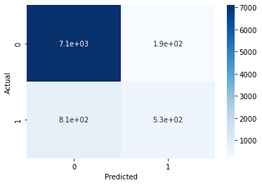

```python
sns.heatmap(cm, annot=True, cmap='Blues')
plt.xlabel('Predicted')
plt.ylabel('Actual')
plt.show()
```

```python
tn, fp, fn, tp = cm.ravel()

accuracy = (tp + tn) / (tp + tn + fp + fn)

accuracy
```

```
0.883559263121307
```

The accuracy of the model is pretty high, which means the model is reasonable.

From the summary information, we can conclude that customers visit in weekdays has a negative impact of generating revenues. We should pay more attention with customers browsing the website on weekends.

## Implications

It is feasible to build a model to predict purchasing intention in an e-commerce environment.

1.Design the website to be more exciting and to increase customer's browsing time, for example, in the "Guess what you like" section, to target users' needs more precisely so that they can stay tuned.

2.Give regular customers some discounts to improve repurchasing rate.

3.Holiday offline purchase is still a mainstream, it is not recommended to invest too much budget to attract customers on holidays.

## Limitations

First, we assume that product related page may be the most relevant factor. However, there is a doubt that whether administration duration has a significant impact on the probability of an event occurring. But this need to be proven in the further analysis.

Second, all these variables are generated from the website angle. We don’t get the information about customers’ profiles. What if the most important factor is the characteristics of customers rather than the website’s design? This is an unknown question to us.

Third, another limiatation is the censoring period. Data for January and April are missing from the table, and our conclusions can only be drawn from the other months.